# Time Series Homework: Chapter 6 Lesson 1 Key

```r
pacman::p_load(
  tidyverse,  # ggplot, mutate(), cleaning...
  tsibble,    # as_tsibble()
  fable,      # model(...), forecast(), tidy(), glance()...
  feasts,     # ACF(), PACF()
  ggtime,     # autoplot() for tsibbles
  patchwork,  # + and / for ggplots
  rio         # import()
)
```

## Data

```r
gdp_ts <- rio::import("https://byuistats.github.io/timeseries/data/gdp_fred.csv") |>
  mutate(year_over_year = gdp_millions / lag(gdp_millions, 4)-1) |>
  mutate(quarter = yearquarter(mdy(quarter))) |>
  filter(quarter >= yearquarter(my("Jan 1990")) & quarter < yearquarter(my("Jan 2025"))) |>
  na.omit() |>
  mutate(t = 1:n()) |>
  mutate(std_t = (t - mean(t)) / sd(t)) |>
  as_tsibble(index = quarter)
```

## Questions

We have worked with AR(p), MA(q), ARMA(p,q) stochastic processes. The theoretical ACF and PACF functions of each model can help us identify which of the three models would be a good fit for a particular time series. From the Time Series Notebook:

**NoteACF and PACF of an $AR(p)$ Process**

|  | AR(p) | MA(q) | ARMA(p,q) |
| --- | --- | --- | --- |
| ACF | Tails off | Cuts off after lag $q$ | Tails off |
| PACF | Cuts off after lag $p$ | Tails off | Tails off |

The table above summarizes the theoretical functions. Each time series is a realization of the stochastic process, so our sample estimates of these functions might be different. The following questions will walk you through the simulation of each of them to illustrate this point.

**AR(3) Simulation**

```r
n <- 10000             # Number of observations
p <- c(0.5, 0.3, 0.1)  # AR coefficients
set.seed(123)          # Setting seed for reproducibility

# Simulate the AR(3) process
ar3 <- arima.sim(n = n, model = list(ar = p), sd = 1)

# Convert to tsibble
ar3_ts <- tibble(index = 1:n, value = ar3) |> as_tsibble(index = index)
```

**MA(3) Simulation**

```r
n <- 10000               # Number of observations
q <- c(-0.7, -0.5, 0.2)  # MA coefficients
set.seed(123)            # For reproducibility

# Simulate the MA(3) process
ma3 <- arima.sim(n = n, model = list(ma = q), sd = 1)

# Convert to tsibble
ma3_ts <- tibble(index = 1:n, value = ma3) |> as_tsibble(index = index)
```

**ARMA(3,3) Simulation**

```r
n <- 10000                # Number of observations
p <- c(0.8, -0.15, 0.05)  # AR coefficients
q <- c(0.8, -0.15, 0.05)  # MA coefficients
set.seed(123)             # For reproducibility

# Simulate the MA(3) process
arma3 <- arima.sim(n = n, model = list(ar = p, ma = q), sd = 1)

# Convert to tsibble
arma3_ts <- tibble(index = 1:n, value = arma3) |> as_tsibble(index = index)
```

##### a) Plot the ACFs for the AR(3) and MA(3) simulations side by side.

**NoteAnswer**

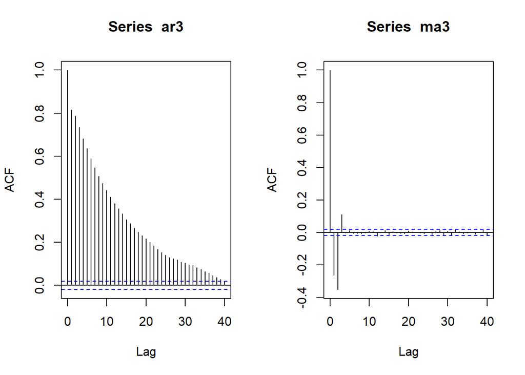

```r
par(mfrow=c(1,2))
acf(ar3)
acf(ma3)
```

##### b) Plot the PACFs for the AR(3) and MA(3) simulations side by side.

**NoteAnswer**

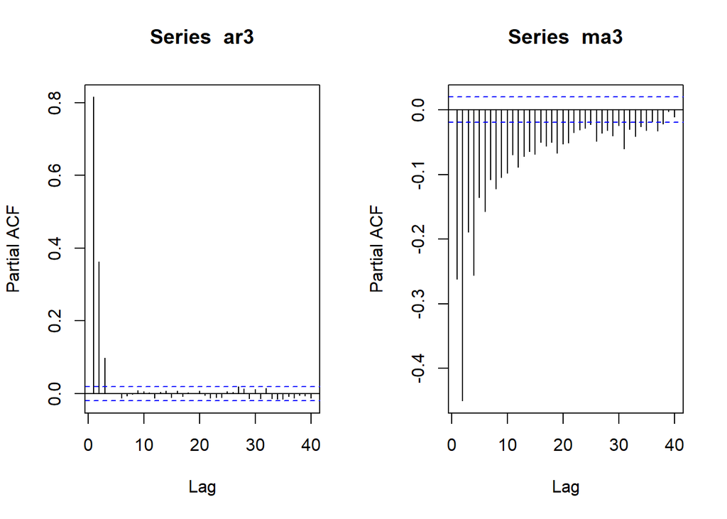

```r
par(mfrow=c(1,2))
pacf(ar3)
pacf(ma3)
```

##### c) Plot the ACF and PACF for the ARMA(3) simulation side by side.

**NoteAnswer**

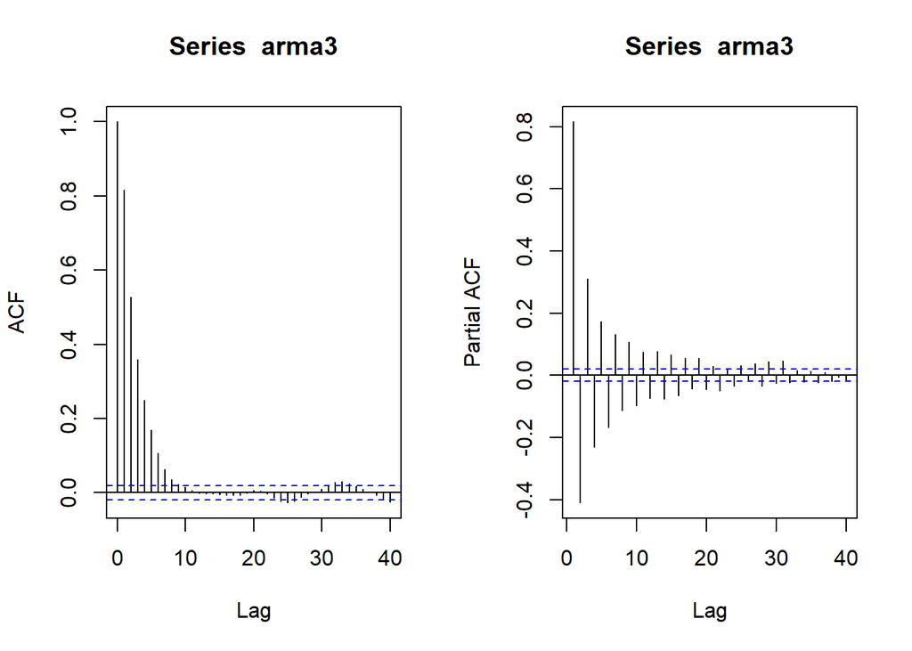

```r
par(mfrow=c(1,2))
acf(arma3)
pacf(arma3)
```

##### d) Does the theoretical ACF and PACF functions described above in Table 1 match with the plots you created? Please change the seed and sample size for the simulation multiple times before answering this question.

**NoteAnswer**

Conceptually, the plots match their descriptions from the above table. Even after changing the seed and sample size multiple times, the patterns remain consistent. The plots’ cutoff point (lag p) varies by sample size, but the shape is repeatable.

### Question 2 - Experimentation

#### a) Go back to the simulation and change the parameters used in the AR process. Show that your new parameters are stationary.

**NoteAnswer**

```r
p <- c(0.5, 0.3, 0.1)  #  New AR coefficients

abs(polyroot(c(-1,-p)))
```

```
[1] 1.972979 2.568946 1.972979
```

All AR roots are above 1, so the process is stationary.

#### b.) Go back to the simulation and change the parameters used in the MA process.Show that the new parameters are invertible.

**NoteAnswer**

```r
q <- c(-0.7, -0.5, 0.2)

abs(polyroot(c(1,-q)))
```

```
[1] 1.150550 1.150550 3.777106
```

All MA roots are greater than 1, so the process is invertible.

#### c.) Plot the acf and pacf of the new simulations. Are the charts still consistent with the table above?

**NoteAnswer**

**Base R**

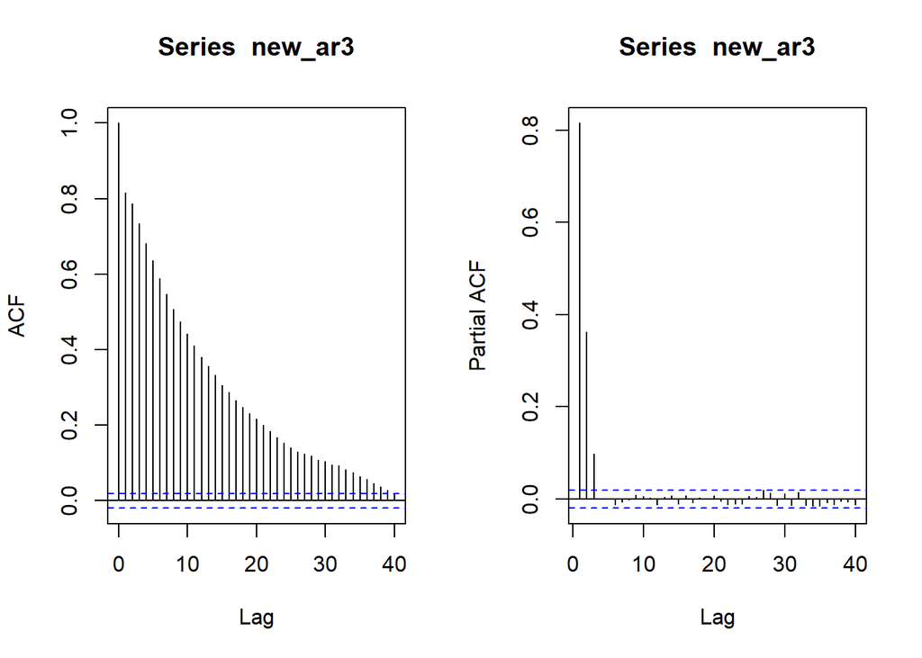

```r
set.seed(123)

new_ar3 <- arima.sim(n, model = list(ar = p))
new_ma3 <- arima.sim(n, model = list(ma = q))

par(mfrow=c(1,2))
acf(new_ar3)
pacf(new_ar3)
```

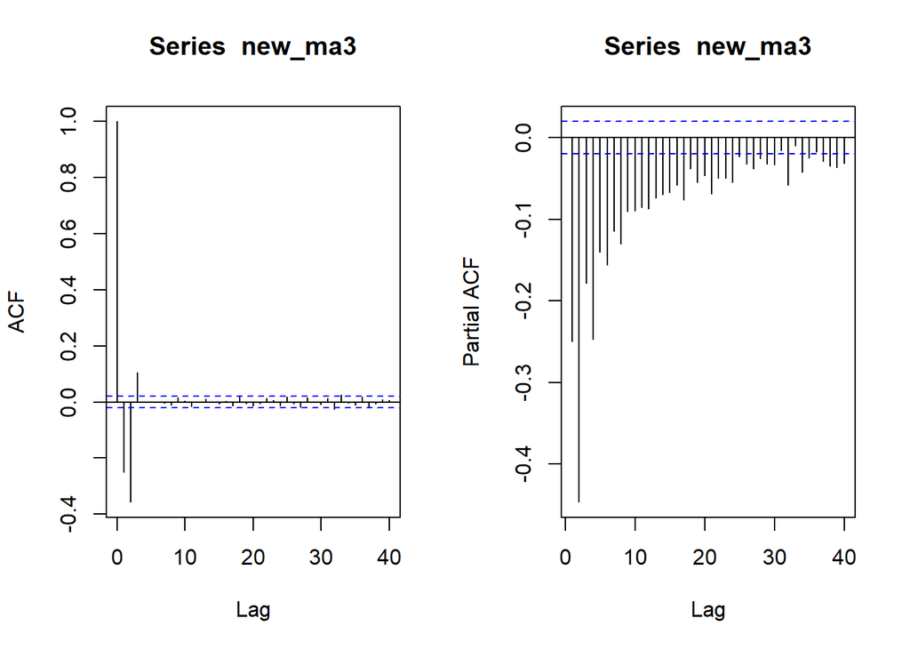

```r
acf(new_ma3)
pacf(new_ma3)
```

**Tidyverts**

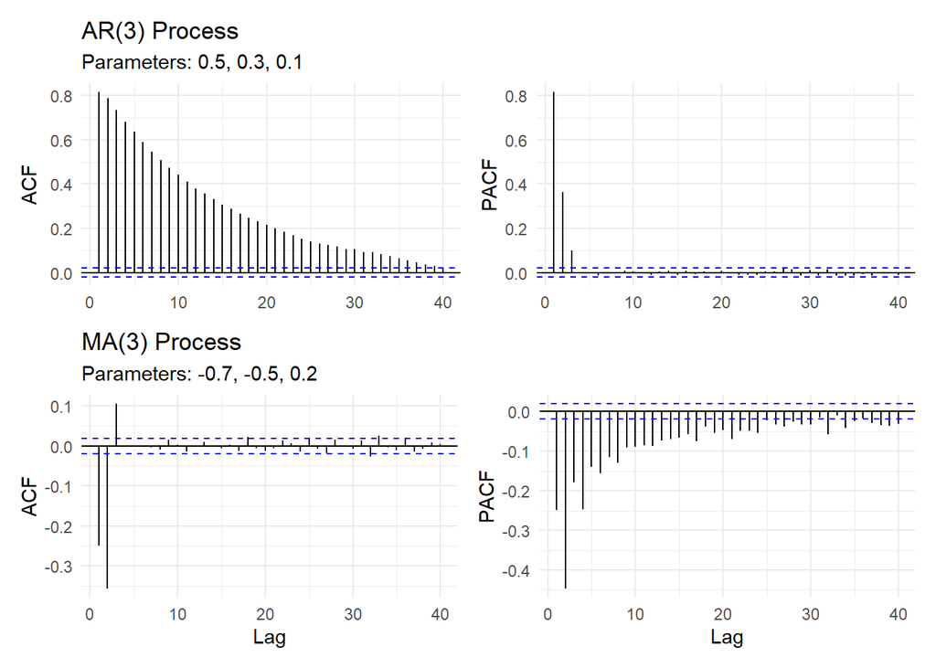

```r
new_ar3_ts <- tibble(index = 1:n, value = new_ar3) |> as_tsibble(index = index)
new_ma3_ts <- tibble(index = 1:n, value = new_ma3) |> as_tsibble(index = index)

ar3_acf <- new_ar3_ts |>
  ACF(value) |>
  autoplot() +
  labs(
    title = "AR(3) Process",
    subtitle = paste0("Parameters: ", p[1], ", ", p[2], ", ", p[3]),
    y = "ACF",
    x = NULL
  ) +
  theme_minimal()

ar3_pacf <- new_ar3_ts |>
  PACF(value) |>
  autoplot() +
  labs(
    y = "PACF",
    x = NULL
  ) +
  theme_minimal()

ma3_acf <- new_ma3_ts |>
  ACF(value) |>
  autoplot() +
  labs(
    title = "MA(3) Process",
    subtitle = paste0("Parameters: ", q[1], ", ", q[2], ", ", q[3]),
    y = "ACF",
    x = "Lag"
  ) +
  theme_minimal()

ma3_pacf <- new_ma3_ts |>
  PACF(value) |>
  autoplot() +
  labs(
    y = "PACF",
    x = "Lag"
  ) +
  theme_minimal()

(ar3_acf + ar3_pacf) / (ma3_acf + ma3_pacf)
```

The shape and pattern of these plots are still consistent with the theoretical framework shown in the table.

**NoteAnswer**

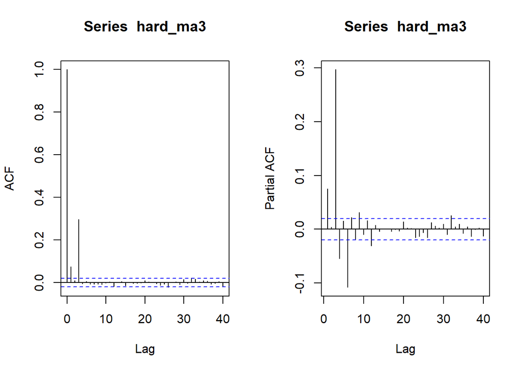

```r
n <- 10000
q <- c(0.7,-0.4, 0.6)  # New MA coefficients
set.seed(123)

hard_ma3 <- arima.sim(n = n, model = list(ma = q), sd = 1)

par(mfrow=c(1,2))
acf(hard_ma3)
pacf(hard_ma3)
```

### Rubric

[output not shown]